# Neural Collaborative Filtering

Embedding lookups, nonlinear interaction, and rating prediction

Ben Dai

CUHK · Department of Statistics and Data Science

## Can a neural network reproduce MF?

$$\widehat r_{ui}=p_u^\top q_i$$

user ID $u$

*→*

lookup $p_u$

*↘*

inner product

*→*

rating

item ID $i$

*→*

lookup $q_i$

*↗*

same output

The first challenge is a reusable layer that turns an ID into its learned factor vector.

## An embedding layer is a learned lookup table

USER TABLE**$P\in\mathbb R^{n\times K}$**

Integer user ID $u$ selects row $p_u$.

ITEM TABLE**$Q\in\mathbb R^{m\times K}$**

Integer item ID $i$ selects row $q_i$.

$$u\longmapsto P[u]=p_u,\qquad i\longmapsto Q[i]=q_i$$

“Embedding” and “latent factor” describe the same kind of learned dense vector here.

## Lookup equals a one-hot matrix product

With three users, ID 2 can be written as a one-hot row $e_2=(0,1,0)$.

$$e_2P=(0,1,0)\begin{bmatrix}p_1^\top\\p_2^\top\\p_3^\top\end{bmatrix}=p_2^\top$$

CONCEPT**select one row**

The one-hot vector explains the mathematics.

IMPLEMENTATION**use a lookup**

An embedding layer retrieves the row without building a huge one-hot array.

## Embedding size is a choice; values are learned

HYPERPARAMETER**$K$ · embedding dimension**

Choose how many coordinates each ID receives before fitting.

LEARNED PARAMETERS**$P$ and $Q$**

Training updates the $nK+mK$ table entries.

$$\texttt{Embedding(input\_dim=n\_users, output\_dim=K)}$$

The ID numbers are lookup positions, not ordered numerical measurements.

## MF is a tiny two-branch network

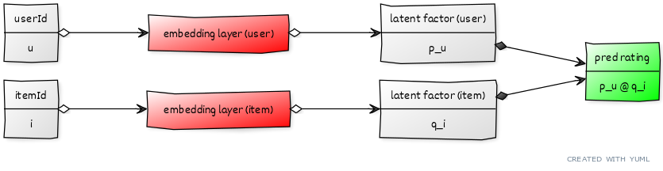

$$u\to p_u,\quad i\to q_i,\quad (p_u,q_i)\to p_u^\top q_i$$

Turning MF into layers does not change its model: the interaction is still an inner product.

## What changes in NCF?

MATRIX FACTORIZATION**Fixed interaction**

$$p_u^\top q_i=\sum_{k=1}^K p_{uk}q_{ik}$$

NEURAL COLLABORATIVE FILTERING**Learn a combination rule**

$$\widehat r_{ui}=g_\theta([p_u,q_i])$$

The brackets mean concatenate the two vectors, then pass the result through a network.

## Follow one prediction through the NCF graph

$u,i$  
integer IDs

*→*

$p_u,q_i$  
embeddings

*→*

$[p_u,q_i]$  
concatenate

*→*

$g_\theta$  
hidden layers

*→*

$\widehat r_{ui}$

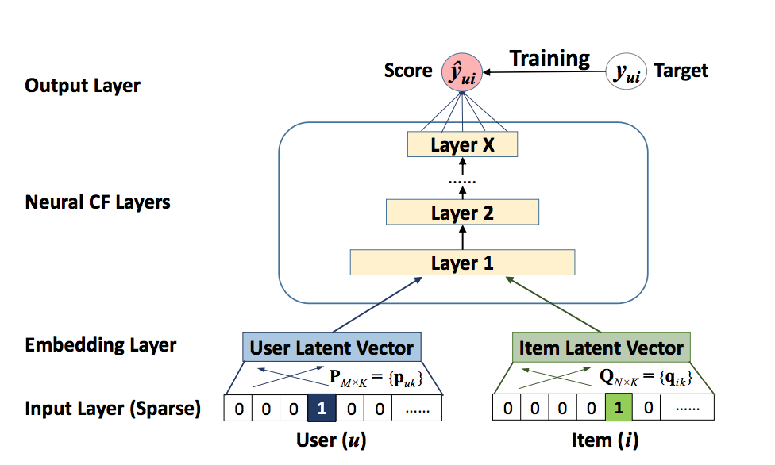

Every observed rating sends an error signal through the hidden layers and back into the two embedding tables.

## NCF: four questions before code

1 · MODEL**$g_\theta([p_u,q_i])$**

Two ID lookups followed by a nonlinear network.

2 · HYPERPARAMETERS**embedding size + architecture**

Choose $K$, depth, width, activation, and training settings.

3 · CRITERION**MSE on observed ratings**

Fit only pairs whose ratings are known in the training fold.

4 · LEARNED**tables + network weights**

$P,Q$ and the hidden/output-layer parameters.

## The rating-regression criterion

$$\min_{P,Q,\theta}\;\frac{1}{|\Omega_{\rm train}|}\sum_{(u,i)\in\Omega_{\rm train}}\bigl(r_{ui}-g_\theta([p_u,q_i])\bigr)^2+\lambda\,\mathrm{Reg}(P,Q,\theta)$$

FIT**Training pairs only**

Gradient updates use observed training ratings.

SELECT**Validation RMSE**

Choose settings and stopping point without touching the final test labels.

This is the explicit-rating version used in STAT3009; the original NCF research also considers implicit feedback.

## A Keras implementation sketch

```python
import keras

user_id = keras.Input(shape=(1,), dtype="int32")
item_id = keras.Input(shape=(1,), dtype="int32")
u = keras.layers.Flatten()(keras.layers.Embedding(n_users, K)(user_id))
i = keras.layers.Flatten()(keras.layers.Embedding(n_items, K)(item_id))
x = keras.layers.Concatenate()([u, i])
x = keras.layers.Dense(32, activation="relu")(x)
rating = keras.layers.Dense(1)(x)
model = keras.Model([user_id, item_id], rating)
model.compile(optimizer="adam", loss="mse")
```

The two embedding layers and Dense layers are all trained by the same loss.

## In-class design: keep the familiar bias terms

$$\widehat r_{ui}=\mu+a_u+b_i+p_u^\top q_i$$

How would this prediction rule become a computational graph?

BRANCH 1**user ID**

Look up $a_u$ and $p_u$.

BRANCH 2**item ID**

Look up $b_i$ and $q_i$.

COMBINE**sum + dot product**

Add $\mu$, both biases, and $p_u^\top q_i$.

A neural framework can implement an existing mathematical model; adding layers is a separate modeling choice.

## Add a nonlinear correction, keep MF

$$\widehat r_{ui}=p_u^\top q_i+h_\phi([s_u,t_i])$$

MF PATH**first-order interaction**

$p_u^\top q_i$ retains the simple, interpretable matching mechanism.

NEURAL PATH**additional interaction**

Separate embeddings $s_u,t_i$ feed a nonlinear correction.

This additive extension is useful when a dot product captures part of the pattern but leaves structured residuals.

## A more flexible path is optional

$$\widehat r_{ui}=\phi\!\left([\,p_u\circ q_i,\;\psi([s_u,t_i])\,]\right)$$

$p_u\circ q_i$**coordinate-wise products**

Keep explicit factor interactions as inputs.

$\psi,\phi$**learned nonlinear functions**

Let the network combine those interactions with another representation.

This extension has more parameters and more design choices; it needs the same careful validation as simpler models.

## When the ID is new

KNOWN ID**Embedding row exists**

Look up its learned vector and predict.

NEW ID**No learned row yet**

The ID-only NCF model cannot infer a personalized vector from an unseen ID.

Side information—user or item features—offers a way to construct a representation for a new entity. That is the next lecture.

## The thread from MF to NCF

MF  
**dot product**

*→*

embedding layers  
**same factors**

*→*

NCF  
**learned interaction**

*→*

side information  
**new IDs**

For each new model, ask again: **model, hyperparameters, fitting criterion, learned parameters**.